# 17483_MY461_Exam

##Libraries preparation For this project the following libraries are being used. Please make sure you have installed these packages before running the file. (All libraries are attached and detached when needed throughout the project.)

```r
#### USED IN THE SEMINARS ######
#install.packages("igraph")
#install.packages("intergraph")
#install.packages("sna")

######### EXTRAS ###########
#install.packages("pheatmap")
#install.packages("formattable")
#install.packages("RColorBrewer")
#install.packages("maps")
```

Loading required packages

```r
require(igraph)
```

Load in the data:

```r
hei_metadata <- read.csv("HEI_metadata.csv", header = T,as.is=TRUE)

main_el <- read.csv("main_el.csv", header = T,as.is=TRUE)
hum_el <- read.csv("hum_el.csv", header = T,as.is=TRUE) #Humanities and Arts subject
soc_el <- read.csv("soc_el.csv", header = T,as.is=TRUE) #Social sciences, Business and Law subject
sci_el <- read.csv("sci_el.csv", header = T,as.is=TRUE) #Science, Mathematics and Computing subject
eng_el <- read.csv("eng_el.csv", header = T,as.is=TRUE) #Engineering, Manufacturing and Construction subject
```

Generate the main network as directed and weighted. The name of the generated network object will be `main_net`.

```r
#The object "main_el" that was created when reading the csv file is in dataframe format representing an edge list with an extra column representing the weight (number of students) of each edge. Here we transform this dataframe to a directed weighted network.

#Create the directed network with the edge attribute "n" to store the weight:
temp_main_net <- graph.data.frame(main_el)

#Create the edge attribute "weight" by copying the edge attribute "n". This way the network is labelled as weighted network:
temp_main_net2<-set.edge.attribute(temp_main_net, "weight", value= E(temp_main_net)$n )

#Delete the edge attribute "n" and get the final version of the main network "main_net":
main_net<- delete_edge_attr(temp_main_net2,"n")

#Delete igraph objects that were created and won't be used further:
rm(temp_main_net)
rm(temp_main_net2)
```

Create the four subject networks as directed and weighted. The names of the generated network objects will be `hum_net`, `soc_net`, `sci_net`, `eng_net.`

```r
#Create the directed networks with the edge attribute "n" to store the weight:
temp_hum_net <- graph.data.frame(hum_el)
temp_soc_net <- graph.data.frame(soc_el)
temp_sci_net <- graph.data.frame(sci_el)
temp_eng_net <- graph.data.frame(eng_el)

#Create the edge attribute "weight" by copying the edge attribute "n". This way the networks are labelled as weighted networks:
temp_hum_net2<-set.edge.attribute(temp_hum_net, "weight", value= E(temp_hum_net)$n )
temp_soc_net2<-set.edge.attribute(temp_soc_net, "weight", value= E(temp_soc_net)$n )
temp_sci_net2<-set.edge.attribute(temp_sci_net, "weight", value= E(temp_sci_net)$n )
temp_eng_net2<-set.edge.attribute(temp_eng_net, "weight", value= E(temp_eng_net)$n )


#Delete the edge attribute "n" and get the final version of the networks:
hum_net<- delete_edge_attr(temp_hum_net2,"n")
soc_net<- delete_edge_attr(temp_soc_net2,"n")
sci_net<- delete_edge_attr(temp_sci_net2,"n")
eng_net<- delete_edge_attr(temp_eng_net2,"n")

#Delete igraph objects that were created and won't be used further:
rm(temp_hum_net)
rm(temp_hum_net2)
rm(temp_soc_net)
rm(temp_soc_net2)
rm(temp_sci_net)
rm(temp_sci_net2)
rm(temp_eng_net)
rm(temp_eng_net2)
```

Generate the reduced main network. The name of the generated network object will be `reduced_net`.

```r
#Delete edges that have a weight less than 5:
reduced_net<- delete_edges(main_net, E(main_net)[E(main_net)$weight<5])

#Delete vertices that have degree=0 (that are isolates):
reduced_net<- delete_vertices(reduced_net, V(reduced_net)[degree(reduced_net)==0])
```

# Question 1

*Calculate the overall metrics (density, average path length, transitivity, and reciprocity) for each of the four subject networks (1. humanities and arts, 2. social sciences, business and law, 3. science, mathematics and computing, 4. engineering, manufacturing and construction).*

```r
hum_dens<- graph.density(hum_net)
hum_apl<- average.path.length(hum_net, directed = TRUE)
hum_trans <-transitivity(hum_net, type='global')
hum_recipr<-reciprocity(hum_net)

soc_dens<- graph.density(soc_net)
soc_apl<- average.path.length(soc_net, directed = TRUE)
soc_trans <-transitivity(soc_net, type='global')
soc_recipr<-reciprocity(soc_net)

sci_dens<- graph.density(sci_net)
sci_apl<- average.path.length(sci_net, directed = TRUE)
sci_trans <-transitivity(sci_net, type='global')
sci_recipr<-reciprocity(sci_net)

eng_dens<- graph.density(eng_net)
eng_apl<- average.path.length(eng_net, directed = TRUE)
eng_trans <-transitivity(eng_net, type='global')
eng_recipr<-reciprocity(eng_net)


#Create a table to present the information that were just calculated
overall_metrics <- data.frame(rbind(
                            c(hum_dens, hum_apl, hum_trans, hum_recipr),
                            c(soc_dens, soc_apl, soc_trans, soc_recipr),
                            c(sci_dens, sci_apl, sci_trans, sci_recipr),
                            c(eng_dens, eng_apl, eng_trans, eng_recipr)
                          ))
rownames(overall_metrics)<- c('Humanities', 'Social Science', 'Science', 'Engineering')
colnames(overall_metrics)<- c('Density', 'Average Path Length', 'Transitivity', 'Reciprocity')
round(overall_metrics,4)#Print the table rounded in 4 decimal places
```

```
##                Density Average Path Length Transitivity Reciprocity
## Humanities      0.0920              2.1874       0.2918      0.5066
## Social Science  0.0972              2.1432       0.3073      0.5656
## Science         0.0455              2.5869       0.1753      0.2613
## Engineering     0.0458              2.5930       0.2895      0.4490
```

*Compare each subject network to a random network with the same number of nodes and edges, created with the Erdős–Rényi model.*

Erdös-Rényi Model:

```r
#The sample_gnm function is used to generate an Erdos-Renyi model, because compared to the sample_gnp network we can control for the exact number of nodes and edges, which is the requirement for the exercise.

#Get the number of vertices and edges in the observed subject networks
hum_vertices<- vcount(hum_net)
hum_edges<- ecount(hum_net)

soc_vertices<- vcount(soc_net)
soc_edges<- ecount(soc_net)

sci_vertices<- vcount(sci_net)
sci_edges<- ecount(sci_net)

eng_vertices<- vcount(eng_net)
eng_edges<- ecount(eng_net)

#Specify the seed for each randomly generated network, to facilitate the discussion later, since results won't change in every new run:
set.seed(1)

#Generate a random network with the same number of nodes and edges, created with the Erdős–Rényi model for each subject network:
hum_erdos <- sample_gnm(n=hum_vertices, m=hum_edges, directed = TRUE)
soc_erdos <- sample_gnm(n=soc_vertices, m=soc_edges, directed = TRUE)
sci_erdos <- sample_gnm(n=sci_vertices, m=sci_edges, directed = TRUE)
eng_erdos <- sample_gnm(n=eng_vertices, m=eng_edges, directed = TRUE)
```

To facilitate the discussion on the comparison:

Create a table with the size of each network (the number of vertices):

```r
number_of_vertices <- data.frame(rbind( c(hum_vertices, hum_edges, hum_dens),
                                        c(soc_vertices, soc_edges, soc_dens),
                                        c(sci_vertices, sci_edges, sci_dens),
                                        c(eng_vertices, eng_edges, eng_dens)
                              ))
rownames(number_of_vertices)<- c('Humanities', 'Social Science', 'Science', 'Engineering')
colnames(number_of_vertices)<- c('Number of Vertices', 'Number of Edges', 'Density')

number_of_vertices
```

```
##                Number of Vertices Number of Edges    Density
## Humanities                    270            6684 0.09202809
## Social Science                287            7978 0.09719549
## Science                       290            3812 0.04548383
## Engineering                   266            3225 0.04575117
```

Create a table with the metrics for the observed and Erdos-Renyi randomly generated networks:

```r
obs_vs_erdos_metrics <- data.frame(rbind(
                            c(hum_dens, hum_apl, hum_trans, hum_recipr),
                            c(graph.density(hum_erdos), average.path.length(hum_erdos), transitivity(hum_erdos, type='global'), reciprocity(hum_erdos)),
                            c(soc_dens, soc_apl, soc_trans, soc_recipr),
                            c(graph.density(soc_erdos), average.path.length(soc_erdos), transitivity(soc_erdos, type='global'), reciprocity(soc_erdos)),
                            c(sci_dens, sci_apl, sci_trans, sci_recipr),
                            c(graph.density(sci_erdos), average.path.length(sci_erdos), transitivity(sci_erdos, type='global'), reciprocity(sci_erdos)),
                            c(eng_dens, eng_apl, eng_trans, eng_recipr),
                            c(graph.density(eng_erdos), average.path.length(eng_erdos), transitivity(eng_erdos, type='global'), reciprocity(eng_erdos))
                              ))
rownames(obs_vs_erdos_metrics)<- c('Observed Humanities network', 'Random Humanities network', 'Observed Social Sciences network', 'Random Social Sciences network', 'Observed Sciences network', 'Random Sciences network', 'Observed Engineering network', 'Random Engineering network')
colnames(obs_vs_erdos_metrics)<- c('Density', 'Average Path Length', 'Transitivity', 'Reciprocity')

round(obs_vs_erdos_metrics, 4) #Print the table rounded in 4 decimal places
```

```
##                                  Density Average Path Length Transitivity
## Observed Humanities network       0.0920              2.1874       0.2918
## Random Humanities network         0.0920              1.9999       0.1755
## Observed Social Sciences network  0.0972              2.1432       0.3073
## Random Social Sciences network    0.0972              1.9657       0.1851
## Observed Sciences network         0.0455              2.5869       0.1753
## Random Sciences network           0.0455              2.4865       0.0912
## Observed Engineering network      0.0458              2.5930       0.2895
## Random Engineering network        0.0458              2.5132       0.0914
##                                  Reciprocity
## Observed Humanities network           0.5066
## Random Humanities network             0.0952
## Observed Social Sciences network      0.5656
## Random Social Sciences network        0.1015
## Observed Sciences network             0.2613
## Random Sciences network               0.0477
## Observed Engineering network          0.4490
## Random Engineering network            0.0434
```

Create a barplot that compares the metrics across the 8 networks

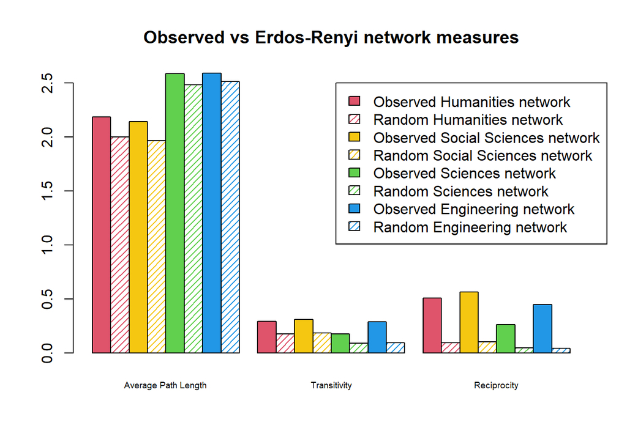

```r
barplot(as.matrix(obs_vs_erdos_metrics[-1])
        ,beside = TRUE
        ,col=c(2, 2, 7, 7, 3 ,3, 4,4)
        ,density = c(1000,20)
        ,cex.names=0.6
        ,legend.text= TRUE
        ,args.legend=list(x=29, y=2.5)
        ,main="Observed vs Erdos-Renyi network measures"
        )
```

# Question 2

Calculate the centrality measures:

```r
#---Degree without weights---
main_deg_in <- degree(main_net, mode="in")

#---Degree with weights---
main_wdeg_in<-strength(main_net,  mode = "in", loops = FALSE, weights = E(main_net)$weight)

#---PageRank Centrality---
#This function interprets edge weights as connection strengths.
main_pr <- page.rank(main_net, directed= TRUE, weights=E(main_net)$weight )$vector
```

Identify the university that has the highest value for each centrality measure:

Degree:

```r
#---In Degree---

#Print the universities and their total degree in a descending order:
main_deg_in_df<-  data.frame(cbind(V(main_net)$name, main_deg_in))

colnames(main_deg_in_df)=c("University", "University Indegree")

head(main_deg_in_df[(order(as.numeric(main_deg_in_df$'University Indegree'), decreasing = TRUE)),])
```

```
##                University University Indegree
## E  GRANADA01 E  GRANADA01                 183
## I  BOLOGNA01 I  BOLOGNA01                 173
## E  MADRID03   E  MADRID03                 171
## CZ PRAHA07     CZ PRAHA07                 170
## S  LUND01       S  LUND01                 156
## E  BARCELO01 E  BARCELO01                 155
```

```r
#---Weighted Degree---
#Print the universities and their total degree in a descending order:
main_wdeg_in_df<-  data.frame(cbind(V(main_net)$name, main_wdeg_in))
colnames(main_wdeg_in_df)=c("University", "Student Indegree")

head(main_wdeg_in_df[(order(as.numeric(main_wdeg_in_df$'Student Indegree'), decreasing = TRUE)),])
```

```
##                University Student Indegree
## E  GRANADA01 E  GRANADA01             1123
## I  BOLOGNA01 I  BOLOGNA01             1053
## E  VALENCI01 E  VALENCI01             1032
## E  MADRID03   E  MADRID03             1026
## CZ PRAHA07     CZ PRAHA07              841
## A  WIEN01       A  WIEN01              697
```

PageRank:

```r
#Print the universities and their PageRank in a descending order:
main_pr_df<-  data.frame(cbind(V(main_net)$name, round(main_pr,4)))
colnames(main_pr_df)=c("Uni", "PageRank")

head(main_pr_df[(order(as.numeric(main_pr_df$PageRank), decreasing = TRUE)),])
```

```
##                       Uni PageRank
## E  GRANADA01 E  GRANADA01   0.0162
## I  BOLOGNA01 I  BOLOGNA01   0.0157
## E  MADRID03   E  MADRID03    0.015
## E  VALENCI01 E  VALENCI01   0.0139
## CZ PRAHA07     CZ PRAHA07   0.0122
## DK KOBENHA01 DK KOBENHA01   0.0119
```

*Plot histograms of your two chosen centrality measures, and overlay vertical lines demarcating the values for each of the London universities.*

In Degree

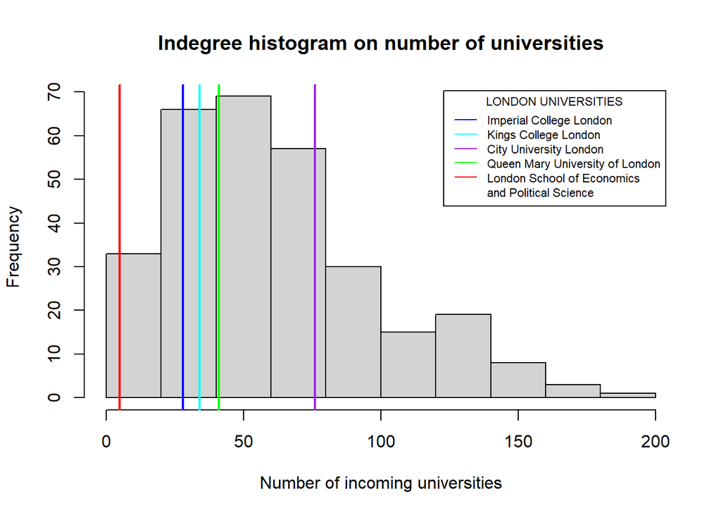

```r
hist(main_deg_in, main="Indegree histogram on number of universities", xlab="Number of incoming universities")

#draw vertical lines to indicate the degree of the London Universities
abline(v=main_deg_in[which(V(main_net)$name =="UK LONDON015")],col="blue",lwd=2)
abline(v=main_deg_in[which(V(main_net)$name =="UK LONDON017")],col="cyan",lwd=2)
abline(v=main_deg_in[which(V(main_net)$name =='UK LONDON029')],col="purple",lwd=2)
abline(v=main_deg_in[which(V(main_net)$name =='UK LONDON031')],col="green",lwd=2)
abline(v=main_deg_in[which(V(main_net)$name =="UK LONDON020")],col="red",lwd=2)


# Add legend
legend("topright",
       inset=.02,
       legend=c('Imperial College London',
                'Kings College London',
                'City University London',
                'Queen Mary University of London',
                'London School of Economics','and Political Science'),
       col=c('blue', 'cyan', 'purple','green', 'red','white'), #the white colour is used so that the LSE name which is long can be written in 2 lines, but without a colour in the second line
       #text.font =8,
       cex =0.7, # size of the letters
       lty=1,
       title = "LONDON UNIVERSITIES"
       )
```

In weighted Degree

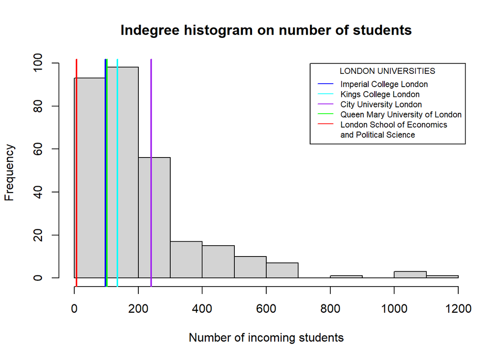

```r
hist(main_wdeg_in, main="Indegree histogram on number of students", xlab="Number of incoming students")

#draw vertical lines to indicate the degree of the London Universities
abline(v=main_wdeg_in[which(V(main_net)$name =="UK LONDON015")],col="blue",lwd=2)
abline(v=main_wdeg_in[which(V(main_net)$name =="UK LONDON017")],col="cyan",lwd=2)
abline(v=main_wdeg_in[which(V(main_net)$name =='UK LONDON029')],col="purple",lwd=2)
abline(v=main_wdeg_in[which(V(main_net)$name =='UK LONDON031')],col="green",lwd=2)
abline(v=main_wdeg_in[which(V(main_net)$name =="UK LONDON020")],col="red",lwd=2)

# Add legend
legend("topright",
       inset=.02,
       legend=c('Imperial College London',
                'Kings College London',
                'City University London',
                'Queen Mary University of London',
                'London School of Economics','and Political Science'),
       col=c('blue', 'cyan', 'purple','green', 'red','white'), #the white colour is used so that the LSE name which is long can be written in 2 lines, but without a colour in the second line
       #text.font =8,
       cex =0.7, # size of the letters
       lty=1,
       title = "LONDON UNIVERSITIES"
       )
```

PageRank:

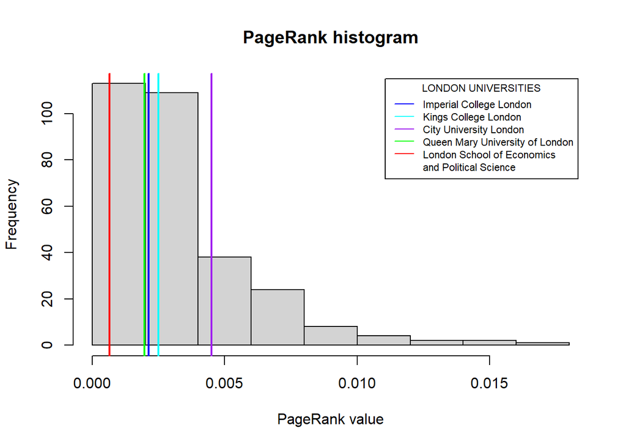

```r
hist(main_pr, main="PageRank histogram", xlab= "PageRank value")

#draw vertical lines to indicate the PageRank of the London Universities
abline(v=main_pr[which(V(main_net)$name =="UK LONDON015")],col="blue",lwd=2)
abline(v=main_pr[which(V(main_net)$name =="UK LONDON017")],col="cyan",lwd=2)
abline(v=main_pr[which(V(main_net)$name =='UK LONDON029')],col="purple",lwd=2)
abline(v=main_pr[which(V(main_net)$name =='UK LONDON031')],col="green",lwd=2)
abline(v=main_pr[which(V(main_net)$name =="UK LONDON020")],col="red",lwd=2)


# Add legend
legend("topright",
       inset=.02,
       legend=c('Imperial College London',
                'Kings College London',
                'City University London',
                'Queen Mary University of London',
                'London School of Economics','and Political Science'),
       col=c('blue', 'cyan', 'purple','green', 'red','white'), #the white colour is used so that the LSE name which is long can be written in 2 lines, but without a colour in the second line
       #text.font =8,
       cex =0.7, # size of the letters
       lty=1,
       title = "LONDON UNIVERSITIES"
       )
```

# Question 3

*Degree distributions* Get the probability of each exact in and out degree. In other words, the proportion of nodes with exactly that degree for each indegree and outdegree from 0 to max(indegree) and max(outdegree) equivalently. This information will form the y-axis in the plots later on.

```r
degree_distr_parameters<- function(the_network, degree_mode){

###Get the indegree, outdegree or total distribution. In particular, get  a numeric vector of the same length as the maximum degree plus one. The first element is the relative frequency zero degree vertices, the second vertices with degree one, etc.
prob <- degree.distribution(the_network, mode=degree_mode)


###Get the in and out degrees for each vertex. This information will form the x-axis in the plots later on.
#Get the indegree of each vertex
deg <- degree(the_network, mode=degree_mode)

###############################################################################################################
###To make the plots that will follow easier to read and less messy, we remove indegree and outdegree values whose probability = 0. (However at this stage we keep the data that informs us about the probability when indegree and outdegree = 0, as it can support our data exploration and understanding, even though it will zoom out our plots a bit).

###Indegree Probability = 0###
#Get the position of elements (indegrees) whose probability is non-zero
prob_nz_pos <- which(prob!=0)

#Remove indegrees with probability=0.
prob_nz_prob <- prob[prob_nz_pos]

#Create a vector that includes all the distinct indegree values, including zero.
degree_scale <- 0:max(deg)

#From the above vector (degree_scale) remove all the zero probability indegree values, so create a vector including all the non-zero-probability indegree values.
degree_nz_prob <- degree_scale[prob_nz_pos]



#In order to plot the complementary cumulative degree distribution function in a log-log scale, we need to remove degree = 0 and its probability, since log(0) is not defined.

# Remove degree=0. The first element of the prob vector contains the proportion of the zero degrees.

prob_nz_probdegree <- prob_nz_prob[-1]
degree_nz_probdegree <- degree_nz_prob[-1]

outlist <- list( prob_nz_prob, degree_nz_prob, deg, prob_nz_probdegree, degree_nz_probdegree)
return(outlist)
}
```

Plot the indegree and outdegree distributions with probability on the y-axis. Indegree distributions:

```r
hum_indegree_distr<-degree_distr_parameters(hum_net, 'in')
soc_indegree_distr<-degree_distr_parameters(soc_net, 'in')
sci_indegree_distr<-degree_distr_parameters(sci_net, 'in')
eng_indegree_distr<-degree_distr_parameters(eng_net, 'in')

#Vectors that store the probabilities of the indegree values only when the probability > 0
hum_prob_nz_prob_in<- as.numeric(unlist(hum_indegree_distr[1]))
soc_prob_nz_prob_in<- as.numeric(unlist(soc_indegree_distr[1]))
sci_prob_nz_prob_in<- as.numeric(unlist(sci_indegree_distr[1]))
eng_prob_nz_prob_in<- as.numeric(unlist(eng_indegree_distr[1]))

#Vectors that store the indegree values only when the probability of them is greater than 0
hum_degree_nz_prob_in <-as.numeric(unlist(hum_indegree_distr[2]))
soc_degree_nz_prob_in <-as.numeric(unlist(soc_indegree_distr[2]))
sci_degree_nz_prob_in <-as.numeric(unlist(sci_indegree_distr[2]))
eng_degree_nz_prob_in <-as.numeric(unlist(eng_indegree_distr[2]))

#Vectors that store the indegree value of each vertex
hum_deg_in <-as.numeric(unlist(hum_indegree_distr[3]))
soc_deg_in <-as.numeric(unlist(soc_indegree_distr[3]))
sci_deg_in <-as.numeric(unlist(sci_indegree_distr[3]))
eng_deg_in <-as.numeric(unlist(eng_indegree_distr[3]))


#Vectors that store the probabilities of the indegree values  when the probability > 0 or its degree > 0
hum_prob_nz_probdeg_in<- as.numeric(unlist(hum_indegree_distr[4]))
soc_prob_nz_probdeg_in<- as.numeric(unlist(soc_indegree_distr[4]))
sci_prob_nz_probdeg_in<- as.numeric(unlist(sci_indegree_distr[4]))
eng_prob_nz_probdeg_in<- as.numeric(unlist(eng_indegree_distr[4]))

#Vectors that store the indegree values when the probability > 0 or the degree > 0
hum_deg_nz_probdeg_in<- as.numeric(unlist(hum_indegree_distr[5]))
soc_deg_nz_probdeg_in<- as.numeric(unlist(soc_indegree_distr[5]))
sci_deg_nz_probdeg_in<- as.numeric(unlist(sci_indegree_distr[5]))
eng_deg_nz_probdeg_in<- as.numeric(unlist(eng_indegree_distr[5]))
```

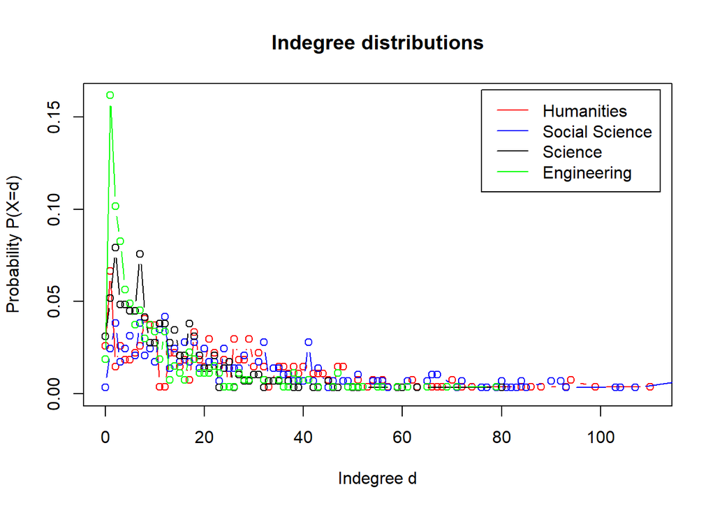

```r
ylimit <- max(hum_prob_nz_prob_in, soc_prob_nz_prob_in, sci_prob_nz_prob_in, eng_prob_nz_prob_in)

# Plot the degree distributions in one graph
plot(hum_prob_nz_prob_in ~ hum_degree_nz_prob_in, xlab='Indegree d', ylab='Probability P(X=d)', ylim=c(0, ylimit),
     col='red', type = 'b', main= 'Indegree distributions')
points(soc_prob_nz_prob_in ~ soc_degree_nz_prob_in, col='blue', type = 'b')
points(sci_prob_nz_prob_in ~ sci_degree_nz_prob_in, col='black', type = 'b')
points(eng_prob_nz_prob_in ~ eng_degree_nz_prob_in, col='green', type = 'b')


# Add legend
legend('topright', inset=.02, legend=c('Humanities', 'Social Science', 'Science', 'Engineering'),
       col=c('red', 'blue', 'black',  'green'), lty=1)
```

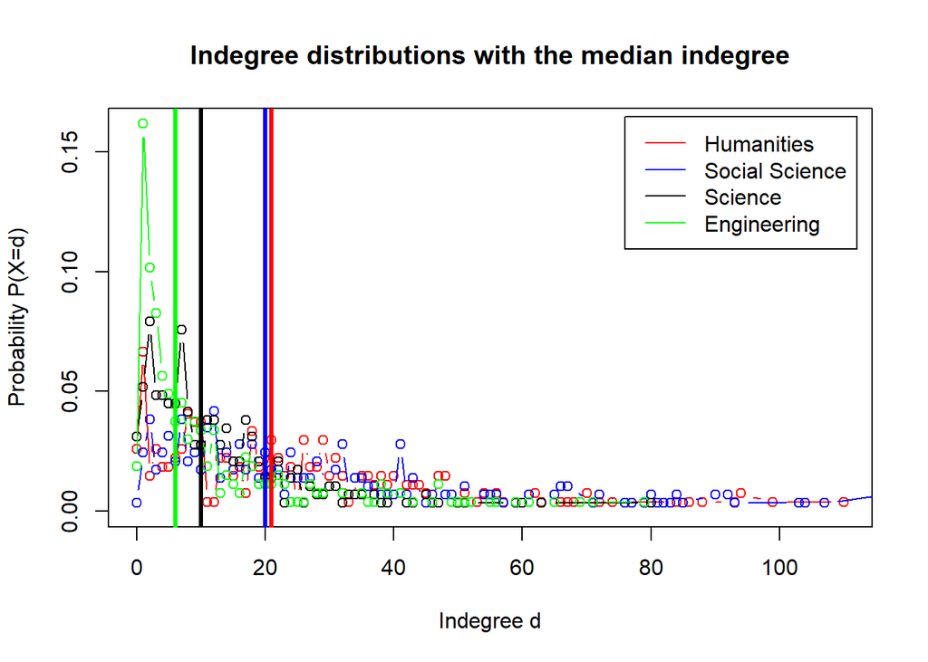

```r
ylimit <- max(hum_prob_nz_prob_in, soc_prob_nz_prob_in, sci_prob_nz_prob_in, eng_prob_nz_prob_in)

# Plot the degree distributions in one graph
plot(hum_prob_nz_prob_in ~ hum_degree_nz_prob_in, xlab='Indegree d', ylab='Probability P(X=d)', ylim=c(0, ylimit),
     col='red', type = 'b', main= 'Indegree distributions with the median indegree')
points(soc_prob_nz_prob_in ~ soc_degree_nz_prob_in, col='blue', type = 'b')
points(sci_prob_nz_prob_in ~ sci_degree_nz_prob_in, col='black', type = 'b')
points(eng_prob_nz_prob_in ~ eng_degree_nz_prob_in, col='green', type = 'b')


# Add legend
legend('topright', inset=.02, legend=c('Humanities', 'Social Science', 'Science', 'Engineering'),
       col=c('red', 'blue', 'black',  'green'), lty=1)

abline(v=median(hum_deg_in),col="red",lwd=3) #draw a vertical red line to indicate the median
abline(v=median(soc_deg_in),col="blue",lwd=3)
abline(v=median(sci_deg_in),col="black",lwd=3)
abline(v=median(eng_deg_in),col="green",lwd=3)
```

Find the degree with the highest probability in the Engineering network, in order to remove it and manage to zoom in the plot.

```r
eng_maxdegree<- which(eng_prob_nz_probdeg_in==max(eng_prob_nz_probdeg_in))
cat(paste("The degree with the highest probability in the Engineering network is degree",eng_maxdegree,"with probability", round(max(eng_prob_nz_probdeg_in),4)))
```

```
## The degree with the highest probability in the Engineering network is degree 1 with probability 0.1617
```

Zoom in the plot by removing the degree= 0 and degree=1:

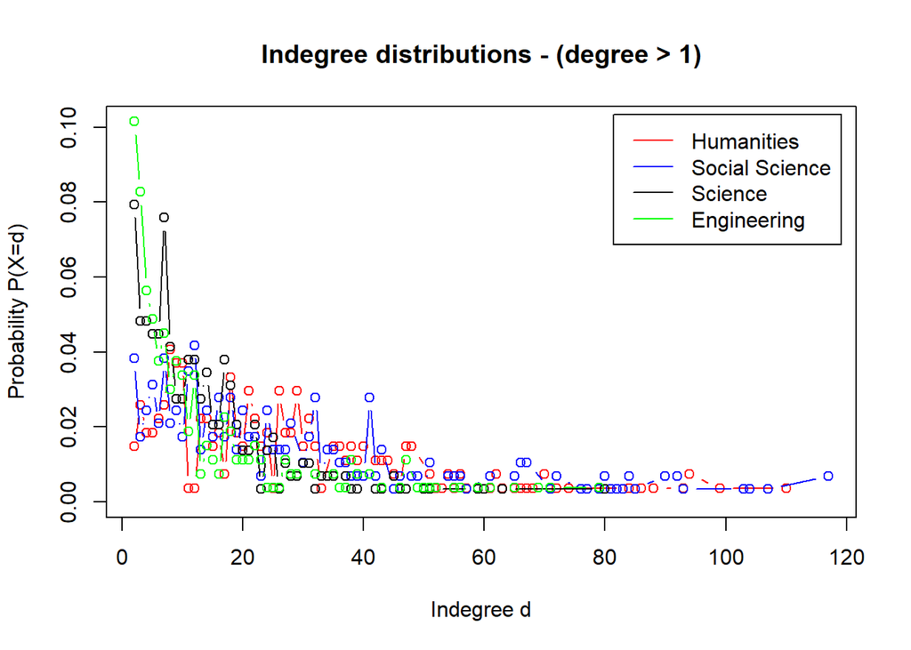

```r
ylimit <- max(hum_prob_nz_probdeg_in[-1], soc_prob_nz_probdeg_in[-1], sci_prob_nz_probdeg_in[-1] , eng_prob_nz_probdeg_in[-1])

xlimit<- max(hum_deg_nz_probdeg_in[-1],soc_deg_nz_probdeg_in[-1], sci_deg_nz_probdeg_in[-1],eng_deg_nz_probdeg_in[-1] )

# Plot the degree distributions in one graph
plot(hum_prob_nz_probdeg_in[-1] ~ hum_deg_nz_probdeg_in[-1], xlab='Indegree d', ylab='Probability P(X=d)', ylim=c(0, ylimit), xlim=c(2,xlimit),
     col='red', type = 'b', main= 'Indegree distributions - (degree > 1)')
points(soc_prob_nz_probdeg_in[-1] ~ soc_deg_nz_probdeg_in[-1], col='blue', type = 'b')
points(sci_prob_nz_probdeg_in[-1] ~ sci_deg_nz_probdeg_in[-1], col='black', type = 'b')
points(eng_prob_nz_probdeg_in[-1] ~ eng_deg_nz_probdeg_in[-1], col='green', type = 'b')


# Add legend
legend('topright', inset=.02, legend=c('Humanities', 'Social Science', 'Science', 'Engineering'),
       col=c('red', 'blue', 'black',  'green'), lty=1)
```

```r
indegree_summary<- data.frame(cbind(
                                    c(sum(hum_deg_in), sum(soc_deg_in), sum(sci_deg_in), sum(eng_deg_in)),
                                    c(max(hum_deg_in), max(soc_deg_in), max(sci_deg_in), max(eng_deg_in)),
                                    c(hum_vertices, soc_vertices, sci_vertices, eng_vertices)
                                    )
                              )
colnames(indegree_summary)<- c('Indegree', 'Max indegree', 'Number of vertices')
rownames(indegree_summary)<- c('Humanities', 'Social Science', 'Science', 'Engineering')
indegree_summary
```

```
##                Indegree Max indegree Number of vertices
## Humanities         6684          110                270
## Social Science     7978          117                287
## Science            3812           80                290
## Engineering        3225           79                266
```

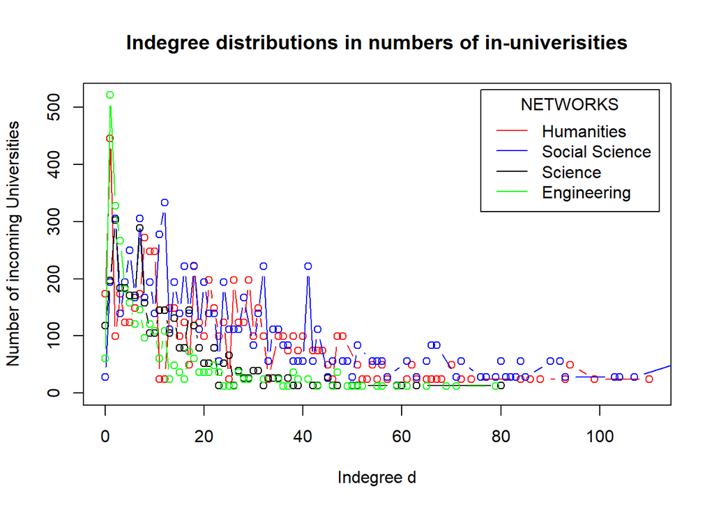

```r
#Calculate the number of universities that have each indegree, by multiplying their probability with the total number of edges that exist in each network.
hum_degree_number_in <- hum_prob_nz_prob_in * hum_edges
soc_degree_number_in <- soc_prob_nz_prob_in * soc_edges
sci_degree_number_in <- sci_prob_nz_prob_in * sci_edges
eng_degree_number_in <- eng_prob_nz_prob_in * eng_edges

ylimit <- max(hum_degree_number_in, soc_degree_number_in, sci_degree_number_in, eng_degree_number_in)

# Plot the degree distributions in one graph
plot(hum_degree_number_in ~ hum_degree_nz_prob_in, xlab='Indegree d', ylab='Number of incoming Universities', ylim=c(0, ylimit),
     col='red', type = 'b', main= 'Indegree distributions in numbers of in-univerisities')
points(soc_degree_number_in ~ soc_degree_nz_prob_in, col='blue', type = 'b')
points(sci_degree_number_in ~ sci_degree_nz_prob_in, col='black', type = 'b')
points(eng_degree_number_in ~ eng_degree_nz_prob_in, col='green', type = 'b')


# Add legend
legend('topright', inset=.02, legend=c('Humanities', 'Social Science', 'Science', 'Engineering'),
       col=c('red', 'blue', 'black',  'green'), lty=1, title='NETWORKS')
```

**Plot the indegree and outdegree distributions as complementary cumulative distribution functions on a log-log scale. Plot the two distribution functions in the same figure.**

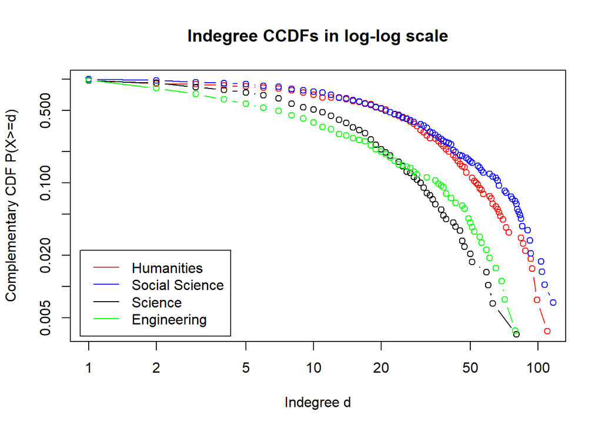

```r
######Indegree##########
# Create a function that loops over the indegree probability vector and sum all values from the current position until the end
ccdf<- function(prob_vector){

  ccdf_in <- NULL
  for (i in 1:length(prob_vector)) {
  ccdf_in[i] = sum( prob_vector[ seq(i, length(prob_vector)) ] )
  }

  return(ccdf_in)

}

hum_ccdf<- ccdf(hum_prob_nz_probdeg_in)
soc_ccdf<- ccdf(soc_prob_nz_probdeg_in)
sci_ccdf<- ccdf(sci_prob_nz_probdeg_in)
eng_ccdf<- ccdf(eng_prob_nz_probdeg_in)

# Plot log complementary indegree CDF on y axis and log indegrees on x axis
plot(hum_ccdf ~ hum_deg_nz_probdeg_in, xlab='Indegree d', ylab='Complementary CDF P(X>=d)', log='xy', col='red', type = 'b', main= "Indegree CCDFs in log-log scale")

points(soc_ccdf ~ soc_deg_nz_probdeg_in, col='blue', type = 'b')
points(sci_ccdf ~ sci_deg_nz_probdeg_in, col='black', type = 'b')
points(eng_ccdf ~ eng_deg_nz_probdeg_in, col='green', type = 'b')

# Add legend
legend('bottomleft', inset=.02, legend=c('Humanities', 'Social Science', 'Science', 'Engineering'),
       col=c('red', 'blue', 'black',  'green'), lty=1)
```

Fit a straight line to the tail of the data:

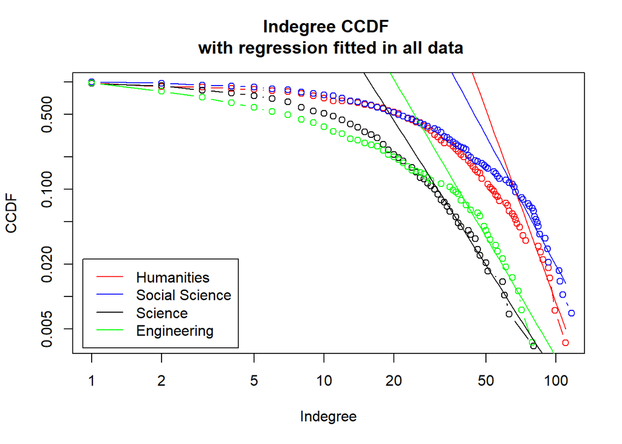

```r
######Indegree- straight line to the tail#######
## Fit a straight line to the tail of the data, excluding the first 100 degrees
hum_reg <- lm( log(tail(hum_ccdf,-62) ) ~ log(tail(hum_deg_nz_probdeg_in,-62)) )
hum_coeff <- coef(hum_reg)

soc_reg <- lm( log(tail(soc_ccdf,-50) ) ~ log(tail(soc_deg_nz_probdeg_in,-50)) )
soc_coeff <- coef(soc_reg)

sci_reg <- lm( log(tail(sci_ccdf,-30) ) ~ log(tail(sci_deg_nz_probdeg_in,-30)) )
sci_coeff <- coef(sci_reg)

eng_reg <- lm( log(tail(eng_ccdf,-30) ) ~ log(tail(eng_deg_nz_probdeg_in,-30)) )
eng_coeff <- coef(eng_reg)


# Plot the data
plot(hum_ccdf ~ hum_deg_nz_probdeg_in, xlab='Indegree', ylab='CCDF', log='xy', col='red',  type = 'b',
     main="Indegree CCDF \n with regression fitted in all data")

points(soc_ccdf ~ soc_deg_nz_probdeg_in, col='blue', type = 'b')
points(sci_ccdf ~ sci_deg_nz_probdeg_in, col='black', type = 'b')
points(eng_ccdf ~ eng_deg_nz_probdeg_in, col='green', type = 'b')

# Use the coefficient to fit a straight line
power_law_fit <- function(x) exp( hum_coeff[[1]] + hum_coeff[[2]]*log(x) )
curve(power_law_fit, col = "red", add = TRUE)

power_law_fit <- function(x) exp( soc_coeff[[1]] + soc_coeff[[2]]*log(x) )
curve(power_law_fit, col = "blue", add = TRUE)

power_law_fit <- function(x) exp( sci_coeff[[1]] + sci_coeff[[2]]*log(x) )
curve(power_law_fit, col = "black", add = TRUE)

power_law_fit <- function(x) exp( eng_coeff[[1]] + eng_coeff[[2]]*log(x) )
curve(power_law_fit, col = "green", add = TRUE)


# Add legend
legend('bottomleft', inset=.02, legend=c('Humanities', 'Social Science', 'Science', 'Engineering'),
       col=c('red', 'blue', 'black',  'green'), lty=1)
```

*Redo the analyses in problem 1 above but using the configuration model (instead of the Erdős–Rényi model).*

Configuration Model:

```r
#We have already defined the indegree for each vertex and stored this information in the numeric vectors 'hum_deg_in' etc. We also need vectors that store the outdegree of each vertex. We calculate this here. These vectors are used here to generate a configuration model accordingly.

hum_deg_out =as.numeric(degree(hum_net, mode="out"))
soc_deg_out =as.numeric(degree(soc_net, mode="out"))
sci_deg_out =as.numeric(degree(sci_net, mode="out"))
eng_deg_out =as.numeric(degree(eng_net, mode="out"))

  set.seed(1) #specify the seed for each randomly generated network, to facilitate the discussion later, since results won't change in every new run
  hum_config <- sample_degseq(out.deg = hum_deg_out, in.deg = hum_deg_in, method = "simple") #the simple method is selected since it allows for loop and multiple edges to be generated. The initial dataset we loaded has no multiple edges for each direction, but has loops.
soc_config <- sample_degseq(out.deg = soc_deg_out, in.deg = soc_deg_in, method = "simple")
sci_config <- sample_degseq(out.deg =sci_deg_out, in.deg = sci_deg_in, method = "simple")
eng_config <- sample_degseq(out.deg = eng_deg_out, in.deg = eng_deg_in, method = "simple")



hum_config_dens<- graph.density(hum_config)
hum_config_apl<- average.path.length(hum_config, directed = TRUE)
hum_config_trans <-transitivity(hum_config, type='global')
hum_config_recipr<-reciprocity(hum_config)

soc_config_dens<- graph.density(soc_config)
soc_config_apl<- average.path.length(soc_config, directed = TRUE)
soc_config_trans <-transitivity(soc_config, type='global')
soc_config_recipr<-reciprocity(soc_config)

sci_config_dens<- graph.density(sci_config)
sci_config_apl<- average.path.length(sci_config, directed = TRUE)
sci_config_trans <-transitivity(sci_config, type='global')
sci_config_recipr<-reciprocity(sci_config)

eng_config_dens<- graph.density(eng_config)
eng_config_apl<- average.path.length(eng_config, directed = TRUE)
eng_config_trans <-transitivity(eng_config, type='global')
eng_config_recipr<-reciprocity(eng_config)


#Create a table to present the information that were just calculated
config_overall_metrics <- data.frame(rbind(
                            c(hum_config_dens, hum_config_apl, hum_config_trans, hum_config_recipr),
                            c(soc_config_dens, soc_config_apl, soc_config_trans, soc_config_recipr),
                            c(sci_config_dens, sci_config_apl, sci_config_trans, sci_config_recipr),
                            c(eng_config_dens, eng_config_apl, eng_config_trans, eng_config_recipr)
                          ))
rownames(config_overall_metrics)<- c('Humanities', 'Social Science', 'Science', 'Engineering')
colnames(config_overall_metrics)<- c('Density', 'Average Path Length', 'Transitivity', 'Reciprocity')
round(config_overall_metrics,4)
```

```
##                Density Average Path Length Transitivity Reciprocity
## Humanities      0.0920              2.2083       0.3032      0.1488
## Social Science  0.0972              2.1640       0.3101      0.1638
## Science         0.0455              2.5910       0.1724      0.0695
## Engineering     0.0458              2.6134       0.2752      0.1483
```

Create table that combines the metrics for the observed and Configuration models in order to use it in a barplot that compares them all.

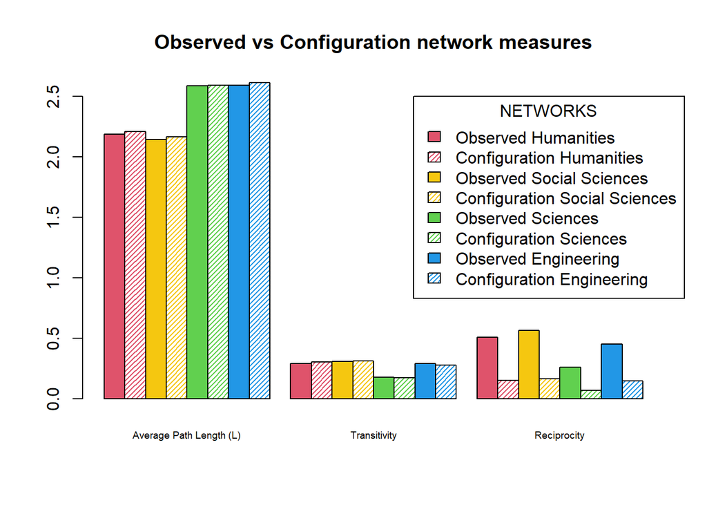

```r
obs_vs_config_metrics <- data.frame(rbind(
                            c(hum_dens, hum_apl, hum_trans, hum_recipr),
                            c(hum_config_dens, hum_config_apl, hum_config_trans, hum_config_recipr),
                            c(soc_dens, soc_apl, soc_trans, soc_recipr),
                            c(soc_config_dens, soc_config_apl, soc_config_trans, soc_config_recipr),
                            c(sci_dens, sci_apl, sci_trans, sci_recipr),
                            c(sci_config_dens, sci_config_apl, sci_config_trans, sci_config_recipr),
                            c(eng_dens, eng_apl, eng_trans, eng_recipr),
                            c(eng_config_dens, eng_config_apl, eng_config_trans, eng_config_recipr)
                              ))
rownames(obs_vs_config_metrics)<- c('Observed Humanities', 'Configuration Humanities', 'Observed Social Sciences', 'Configuration Social Sciences', 'Observed Sciences', 'Configuration Sciences', 'Observed Engineering', 'Configuration Engineering')
colnames(obs_vs_config_metrics)<- c('Density', 'Average Path Length (L)', 'Transitivity', 'Reciprocity')




barplot(as.matrix(obs_vs_config_metrics[-1])
        ,beside = TRUE
        ,col=c(2, 2, 7, 7, 3 ,3, 4,4)
        ,density = c(1000,30)
        ,cex.names=0.6
        ,legend.text= TRUE
        ,args.legend=list(x=29, y=2.5, title='NETWORKS')
        ,main="Observed vs Configuration network measures"
        )
```

# Question 4

*Calculate the probability of a student exchange tie within and between each region (using a blockmodel approach) for the reduced network.*

Add the university region as a vertex attribute in the reduced network:

```r
attribute_vector <- c() #initialize the vector to store the values of the new attribute
for (i in V(reduced_net)$name){ #loop through the names of vertices of the network
  attribute_vertex_value <- hei_metadata[hei_metadata$Erasmus.ID == i,][1,'Region']#select value from the selected column when the Erasmus.ID column from the metadata file matched the name of the vertex
  attribute_vector <- c(attribute_vector, attribute_vertex_value)
}
V(reduced_net)$region <- attribute_vector #Make the created vector a vertex attribute
```

Generate a new (numeric) vertex attribute that will link the region of each university to a number. This number will be used in the blockmodel function later on. Before doing that we print the distinct values of the region vertex attribute, to use them in the code after and we ensure that there are no universities (vertices) with a missing value on the region.

```r
table(V(reduced_net)$region)
```

```
##
##  Eastern Europe Northern Europe Southern Europe  Western Europe
##              25              72              94             101
```

```r
#Generate a numeric region vertex attribute
V(reduced_net)$region_n<- ifelse (V(reduced_net)$region == "Eastern Europe",1, #Each university will have number 1 if its region is Eastern Europe
               ifelse(V(reduced_net)$region == "Northern Europe",2, #Each university will have number 2 if its caste is Northern Europe
                         ifelse(V(reduced_net)$region == "Southern Europe",3, 4))) #Each university will have number 3 if its region is Southern Europe and number 4 otherwise (meaning Western Europe)
```

Switch packages from igraph to the statnet suite of packages, which includes the sna package, in order to use the `blockmodel()` function.

```r
require(intergraph)
detach(package:igraph)
require(sna)
```

Transform the igraph graph object (reduced_net) into a statnet graph object (reduced_statnet)

```r
reduced_statnet<-asNetwork(reduced_net) ## this is the function from intergraph that takes a igraph graph object and makes it into a statnet graph object
```

Determine the probability of ties within and between the regions:

```r
reduced_bm<-blockmodel(reduced_statnet,ec = reduced_statnet %v% "region_n")$block.model ## save the matrix showing the probability of ties within and between each region, the block model
```

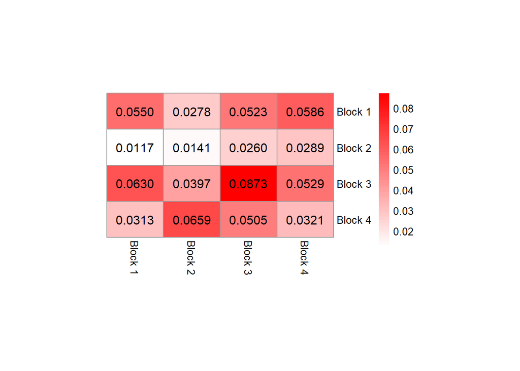

```r
#Print the matrix by using the pheatmap library and method, which visualizes it in a way to facilitate the discussion after. The method colour grades the matrix based on the magnitude of the value. The darker the colour, the higher the value.
library("pheatmap")
pheatmap(reduced_bm #the matrix
         ,display_numbers = TRUE
         ,number_format = "%.4f" #specifies the decimal places to display
         ,fontsize_number= 12
         ,number_color= "black"
         ,cellwidth = 55
         ,cellheight = 35
         ,cluster_row = FALSE
         ,cluster_cols = FALSE
         ,color = colorRampPalette(c("white", "red"))(50) #the colours to use
         )
```

```r
detach(package:pheatmap)
```

```r
reduced_bm_rowsum<-cbind(reduced_bm, total = rowSums(reduced_bm))#create a new column named "total" that will store the sum from each row, in other words the number of households that belong to each caste.
reduced_bm_colsum<-rbind(reduced_bm_rowsum, total = colSums(reduced_bm_rowsum))#create a new row named "total" that will store the sum from each column, in other words the number of households that belong to each membership/cluster.
reduced_bm_colsum
```

```
##            Block 1    Block 2    Block 3    Block 4      total
## Block 1 0.05500000 0.02777778 0.05234043 0.05861386 0.19373206
## Block 2 0.01166667 0.01408451 0.02600473 0.02887789 0.08063379
## Block 3 0.06297872 0.03974586 0.08727980 0.05287550 0.24287989
## Block 4 0.03128713 0.06586909 0.05045292 0.03207921 0.17968834
## total   0.16093252 0.14747723 0.21607787 0.17244646 0.69693408
```

*Evaluate the structural equivalency of the countries using the main network.*

```r
require(igraph)
require(gplots)
#Transform the igraph nework object to an adjacency matrix
main_adj<- get.adjacency(main_net, names=TRUE, attr= "weight")

#Transform the adjacency matrix to a simple matrix
main_matrix <- as.matrix(main_adj)

#Get the transpose of the main adjacency matrix and append it to the main_matrix, because the main network is directed and hence we want to consider the corresponce between nodes for both outgoing and incoming ties
main_adj_transp<-t(main_matrix)

#Stacking one matrix on top of the other
main_matrix_2 <- rbind(main_matrix,
                  main_adj_transp)

#We want larger values to mean greater distance, so we’ll subtract the Pearson correlation values from 1, and tell R to treat it as a distance measure. So the matrix below is a matrix of dissimilarity.
main_dist <- as.dist(1 - cor(main_matrix_2), upper = F)
```

So, now we have the distances between each pair of nodes, meaning our measure of their structural equivalence.

*Use the results of the structural equivalency calculation to divide the countries into six equivalency classes.*

Divide universities into 6 clusters using hierarchical clustering:

```r
main_dend <- hclust(main_dist)

main_partit <- cutree(main_dend, k = 6)
```

*Plot the main network with nodes positioned by their latitude/longitude (so that your network should look roughly like a map of Europe) and nodes coloured by their equivalency class.*

Add the university latitude and longtitude as vertex attributes in the main network:

```r
#Add latitude
attribute_vector <- c() #initialize the vector to store the values of the new attribute
for (i in V(main_net)$name){ #loop through the names of vertices of the network
  attribute_vertex_value <- hei_metadata[hei_metadata$Erasmus.ID == i,][1,'Latitude']#select value from the selected column when the Erasmus.ID column from the metadata file matched the name of the vertex
  attribute_vector <- c(attribute_vector, attribute_vertex_value)
}
V(main_net)$latitude <- attribute_vector #Make the created vector a vertex attribute



#Add longtitude
attribute_vector <- c() #initialize the vector to store the values of the new attribute
for (i in V(main_net)$name){ #loop through the names of vertices of the network
  attribute_vertex_value <- hei_metadata[hei_metadata$Erasmus.ID == i,][1,'Longitude']#select value from the selected column when the Erasmus.ID column from the metadata file matched the name of the vertex
  attribute_vector <- c(attribute_vector, attribute_vertex_value)
}
V(main_net)$longitude <- attribute_vector #Make the created vector a vertex attribute
```

```r
V(main_net)$degree<-degree(main_net)

V(main_net)$wdegree<-strength(main_net,  mode = "all", loops = FALSE, weights = E(main_net)$weight)
```

Switch packages from igraph to the statnet suite of packages, which includes the sna package:

```r
require(intergraph)
detach(package:igraph)
require(sna)
library(network)  # basic 'statnet' network library
library(maps) # basic R map plotting library
```

Transform the igraph graph object (main_net) into a statnet graph object (main_net)

```r
main_statnet<-asNetwork(main_net) ## this is the function from intergraph that takes a igraph graph object and makes it into a statnet graph object
```

Create a vector with the European countries as they appear in the region of the world database of the`map()` function:

```r
europe<- c("Albania","Andorra","Austria","Belarus","Belgium", "Bosnia and Herzegovina", "Bulgaria","Croatia", "Cyprus", "Czech Republic", "Denmark","Estonia",
           "Finland", "France",
"Germany",
"Greece",
"Hungary",
"Iceland",
"Ireland",
"Italy",
"Kosovo",
"Latvia",
"Liechtenstein",
"Lithuania",
"Luxembourg",
"Republic of Macedonia",
"Malta",
"Moldova",
"Monaco",
"Montenegro",
"Netherlands",
"Norway",
"Poland",
"Portugal",
"Romania",
"San Marino",
"Serbia",
"Slovakia",
"Slovenia",
"Spain",
"Sweden",
"Switzerland",
"Turkey",
"Ukraine",
"UK",
"Vatican City",
"Canary Islands"
)
```

Plot the main network on top of the map of europe:

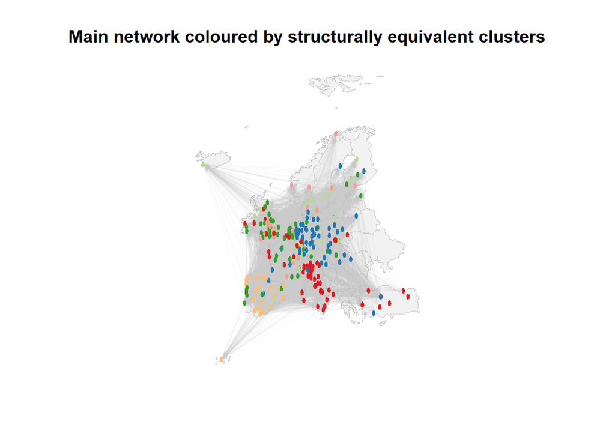

```r
library('RColorBrewer')
pal7<- brewer.pal(7,"Paired")

# plot the map for the background
x<-map(database= 'world',  region =europe, fill=TRUE, col='#f2f2f2', border ='grey',lwd=0.08)

# plot the network using the geo coordinates
plot.network(main_statnet,  # pass in the network
             # don't erase the map before drawing the network
             new=FALSE,
             # get coordiantes from vertices and pass in as 2-col matrix
             coord=cbind(main_statnet%v%'longitude',main_statnet%v%'latitude'),

             # set a semi-transparent edge color
             edge.col= as.color('grey', opacity= 0.04),
             # set the vertex size
             vertex.cex=0.8,
             # set a semi transparent vertex color
             vertex.col=pal7[main_partit+1] ,
             vertex.border=NA,
             # don't jitter the points around
             jitter=FALSE
             )

title(main="Main network coloured by structurally equivalent clusters")
```

```r
#Add a legend to explain the maximum core membership that each colour represents
# legend("topleft",
#        legend=c(1:6),
#        col = pal7[(2:7)],
#        pch = 16,
#        title = "Clusters")
```

Subset the network 6 times based on the 6 clusters

```r
main_cluster1<- main_statnet %s% which(main_partit ==1)
main_cluster2<- main_statnet %s% which(main_partit ==2)
main_cluster3<- main_statnet %s% which(main_partit ==3)
main_cluster4<- main_statnet %s% which(main_partit ==4)
main_cluster5<- main_statnet %s% which(main_partit ==5)
main_cluster6<- main_statnet %s% which(main_partit ==6)
```

Plot clusters separetely:

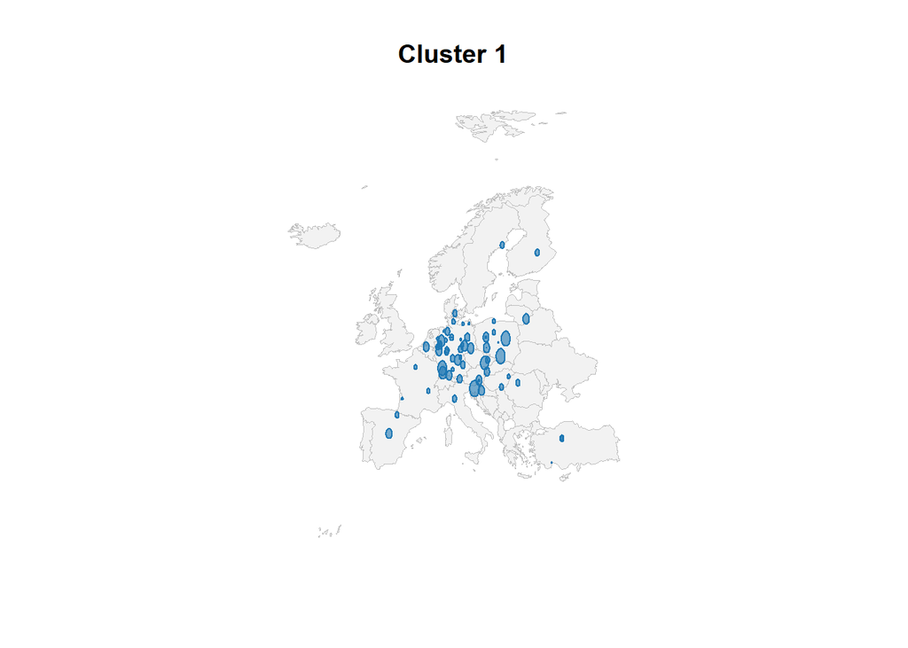

```r
# plot the map for the background
map(database= 'world',  region =europe, fill=TRUE,col='#f2f2f2',border ='grey',lwd=0.08)

# plot the network using the geo coordinates
plot.network(main_cluster1,  # pass in the network
             # don't erase the map before drawing the network
             new=FALSE,
             # get coordiantes from vertices and pass in as 2-col matrix
             coord=cbind(main_cluster1%v%'longitude',main_cluster1%v%'latitude'),

             # set a semi-transparent edge color '#AA555555'
             edge.col= as.color('grey', opacity= 0),
             # set the vertex size
             vertex.cex = (main_cluster1%v%'degree')/100,
             # set a semi transparent vertex color
             vertex.col= as.color(pal7[rep(1+1,(network.size(main_cluster1)))], opacity= 0.6) ,
             vertex.border=as.color(pal7[rep(1+1,(network.size(main_cluster1)))], opacity= 1),
             # don't jitter the points around
             jitter=FALSE
             )
title(main="Cluster 1")
```

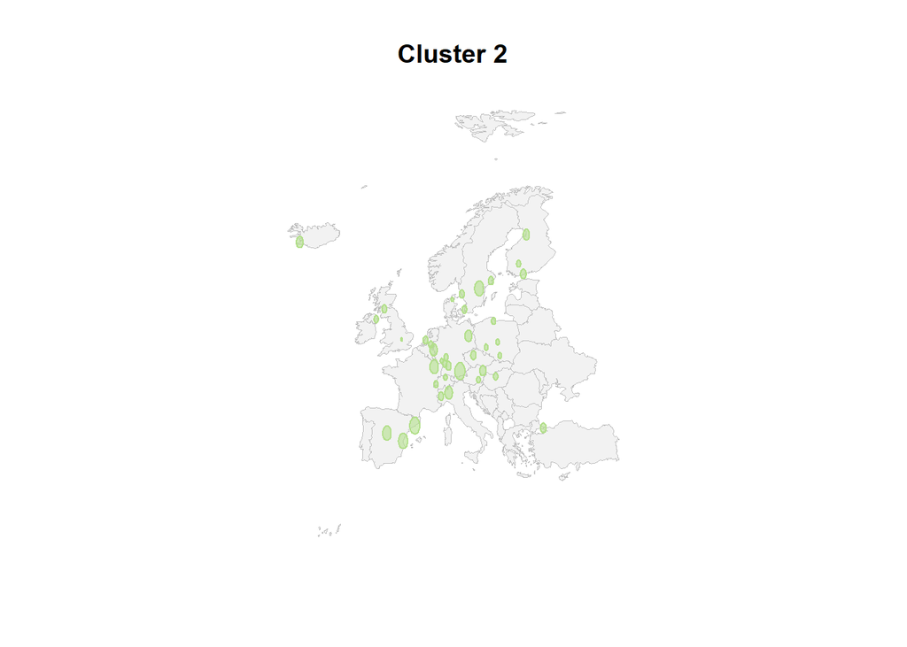

```r
###Cluster 2
# plot the map for the background
map(database= 'world',  region =europe, fill=TRUE,col='#f2f2f2',border ='grey',lwd=0.08)

# plot the network using the geo coordinates
plot.network(main_cluster2,  # pass in the network
             # don't erase the map before drawing the network
             new=FALSE,
             # get coordiantes from vertices and pass in as 2-col matrix
             coord=cbind(main_cluster2%v%'longitude',main_cluster2%v%'latitude'),

             # set a semi-transparent edge color '#AA555555'
             edge.col= as.color('grey', opacity= 0),
             # set the vertex size
             vertex.cex = (main_cluster2%v%'degree')/100,
             # set a semi transparent vertex color
             vertex.col= as.color(pal7[rep(2+1,(network.size(main_cluster2)))], opacity= 0.6) ,
             vertex.border=as.color(pal7[rep(2+1,(network.size(main_cluster2)))], opacity= 1),                      vertex.lty.width= 0.1,
             # don't jitter the points around
             jitter=FALSE
             )
title(main="Cluster 2")
```

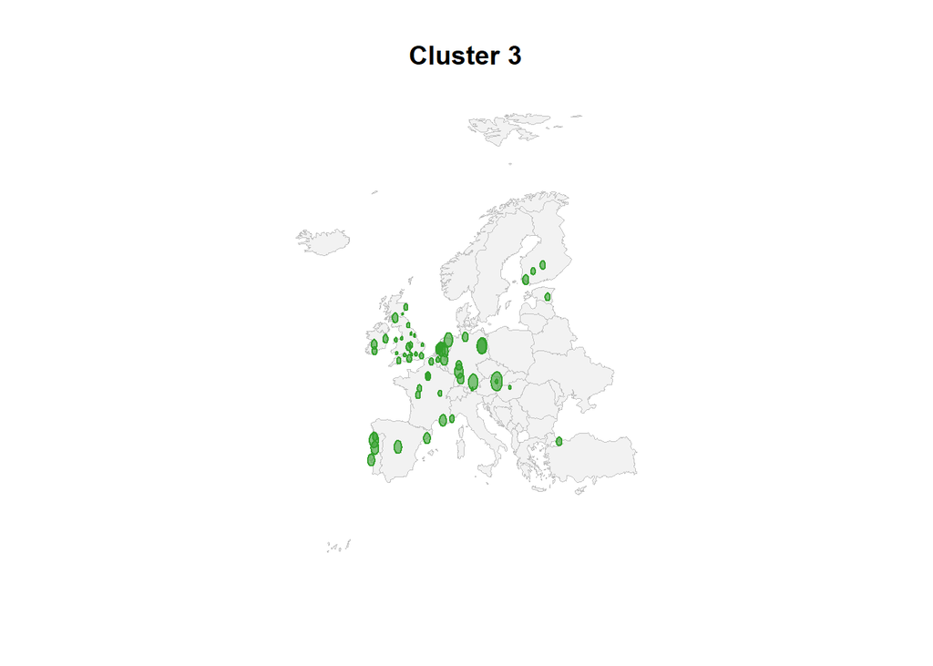

```r
###Cluster 3
# plot the map for the background
map(database= 'world',  region =europe, fill=TRUE,col='#f2f2f2',border ='grey',lwd=0.08)

# plot the network using the geo coordinates
plot.network(main_cluster3,  # pass in the network
             # don't erase the map before drawing the network
             new=FALSE,
             # get coordiantes from vertices and pass in as 2-col matrix
             coord=cbind(main_cluster3%v%'longitude',main_cluster3%v%'latitude'),

             # set a semi-transparent edge color '#AA555555'
             edge.col= as.color('grey', opacity= 0),
             # set the vertex size
             vertex.cex = (main_cluster3%v%'degree')/100,
             # set a semi transparent vertex color
             vertex.col= as.color(pal7[rep(3+1,(network.size(main_cluster3)))], opacity= 0.6) ,
             vertex.border=as.color(pal7[rep(3+1,(network.size(main_cluster3)))], opacity= 1),
             vertex.lty.width= 0.1,
             # don't jitter the points around
             jitter=FALSE
             )
title(main="Cluster 3")
```

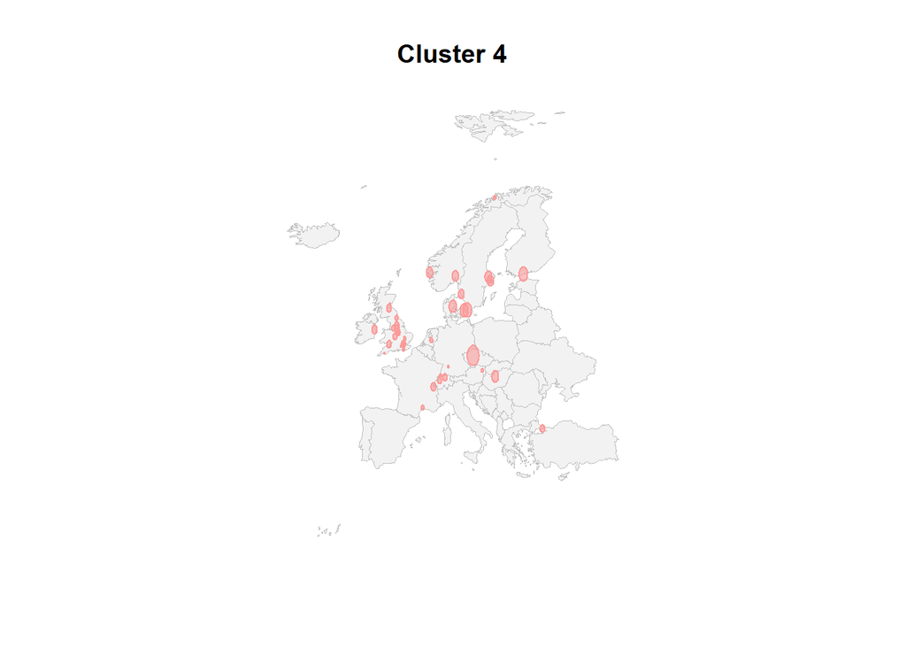

```r
###Cluster 4
# plot the map for the background
map(database= 'world',  region =europe, fill=TRUE,col='#f2f2f2',border ='grey',lwd=0.08)

# plot the network using the geo coordinates
plot.network(main_cluster4,  # pass in the network
             # don't erase the map before drawing the network
             new=FALSE,
             # get coordiantes from vertices and pass in as 2-col matrix
             coord=cbind(main_cluster4%v%'longitude',main_cluster4%v%'latitude'),

             # set a semi-transparent edge color '#AA555555'
             edge.col= as.color('grey', opacity= 0),
             # set the vertex size
             vertex.cex = (main_cluster4%v%'degree')/100,
             # set a semi transparent vertex color
             vertex.col= as.color(pal7[rep(4+1,(network.size(main_cluster4)))], opacity= 0.6) ,
             vertex.border=as.color(pal7[rep(4+1,(network.size(main_cluster4)))], opacity= 1),
             # don't jitter the points around
             jitter=FALSE
             )
title(main="Cluster 4")
```

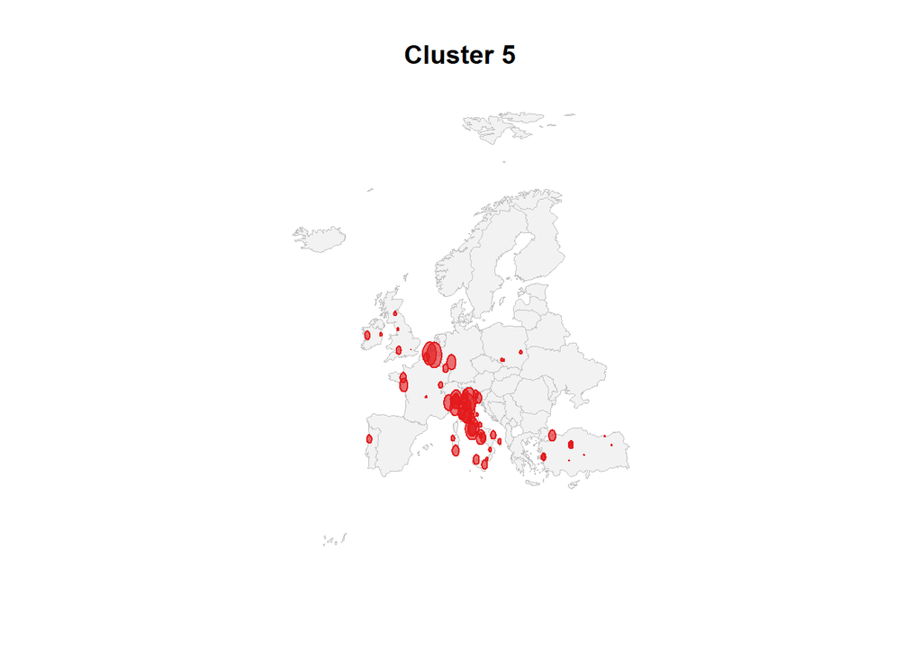

```r
###Cluster 5
# plot the map for the background
map(database= 'world',  region =europe, fill=TRUE,col='#f2f2f2',border ='grey',lwd=0.08)

# plot the network using the geo coordinates
plot.network(main_cluster5,  # pass in the network
             # don't erase the map before drawing the network
             new=FALSE,
             # get coordiantes from vertices and pass in as 2-col matrix
             coord=cbind(main_cluster5%v%'longitude',main_cluster5%v%'latitude'),

             # set a semi-transparent edge color '#AA555555'
             edge.col= as.color('grey', opacity= 0),
             # set the vertex size
             vertex.cex = (main_cluster5%v%'degree')/100,
             # set a semi transparent vertex color
             vertex.col= as.color(pal7[rep(5+1,(network.size(main_cluster5)))], opacity= 0.6) ,
             vertex.border=as.color(pal7[rep(5+1,(network.size(main_cluster5)))], opacity= 1),
             # don't jitter the points around
             jitter=FALSE
             )
title(main="Cluster 5")
```

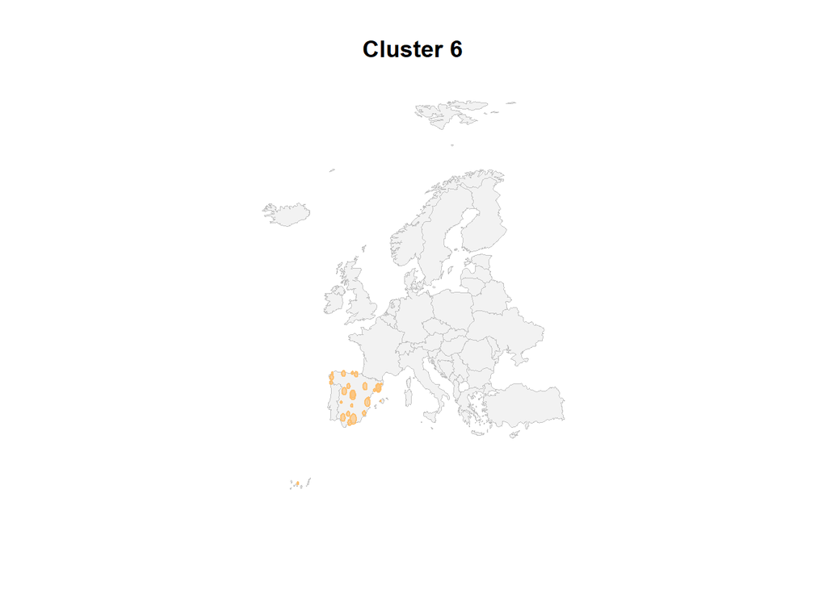

```r
###Cluster 6
# plot the map for the background
map(database= 'world',  region =europe, fill=TRUE,col='#f2f2f2',border ='grey',lwd=0.08)

# plot the network using the geo coordinates
plot.network(main_cluster6,  # pass in the network
             # don't erase the map before drawing the network
             new=FALSE,
             # get coordiantes from vertices and pass in as 2-col matrix
             coord=cbind(main_cluster6%v%'longitude',main_cluster6%v%'latitude'),

             # set a semi-transparent edge color '#AA555555'
             edge.col= as.color('grey', opacity= 0),
             # set the vertex size
             vertex.cex = (main_cluster6%v%'degree')/100,
             # set a semi transparent vertex color
             vertex.col= as.color(pal7[rep(6+1,(network.size(main_cluster6)))], opacity= 0.6) ,
             vertex.border=as.color(pal7[rep(6+1,(network.size(main_cluster6)))], opacity= 1),
             # don't jitter the points around
             jitter=FALSE
             )
title(main="Cluster 6")
```

Plot clusters separately with the vertex size representing the real degree of the vertex:

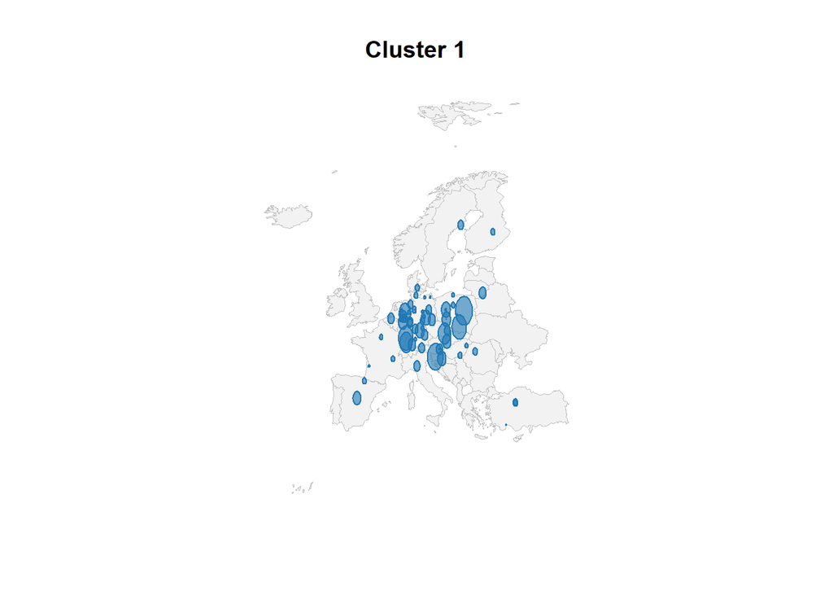

```r
# plot the map for the background
map(database= 'world',  region =europe, fill=TRUE,col='#f2f2f2',border ='grey',lwd=0.08)

# plot the network using the geo coordinates
plot.network(main_cluster1,  # pass in the network
             # don't erase the map before drawing the network
             new=FALSE,
             # get coordinates from vertices and pass in as 2-col matrix
             coord=cbind(main_cluster1%v%'longitude',main_cluster1%v%'latitude'),
             # set a semi-transparent edge color
             edge.col= as.color('grey', opacity= 0),
             # set the vertex size
             vertex.cex = (main_cluster1%v%'wdegree')/200,
             # set a semi transparent vertex color
             vertex.col= as.color(pal7[rep(1+1,(network.size(main_cluster1)))], opacity= 0.6) ,
             vertex.border=as.color(pal7[rep(1+1,(network.size(main_cluster1)))], opacity= 1),
             # don't jitter the points around
             jitter=FALSE
             )
title(main="Cluster 1")
```

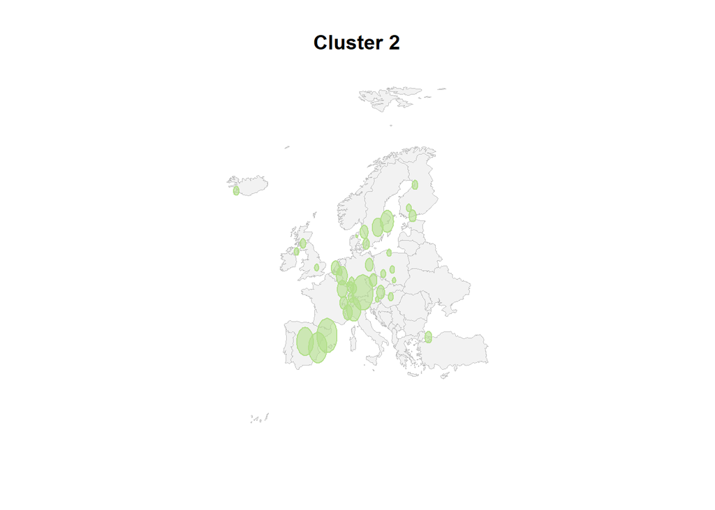

```r
###Cluster 2
# plot the map for the background
map(database= 'world',  region =europe, fill=TRUE,col='#f2f2f2',border ='grey',lwd=0.08)

# plot the network using the geo coordinates
plot.network(main_cluster2,  # pass in the network
             # don't erase the map before drawing the network
             new=FALSE,
             # get coordiantes from vertices and pass in as 2-col matrix
             coord=cbind(main_cluster2%v%'longitude',main_cluster2%v%'latitude'),
             # set a semi-transparent edge color
             edge.col= as.color('grey', opacity= 0),
             # set the vertex size
             vertex.cex = (main_cluster2%v%'wdegree')/200,
             # set a semi transparent vertex color
             vertex.col= as.color(pal7[rep(2+1,(network.size(main_cluster2)))], opacity= 0.6) ,
             vertex.border=as.color(pal7[rep(2+1,(network.size(main_cluster2)))], opacity= 1),                      vertex.lty.width= 0.1,
             # don't jitter the points around
             jitter=FALSE
             )
title(main="Cluster 2")
```

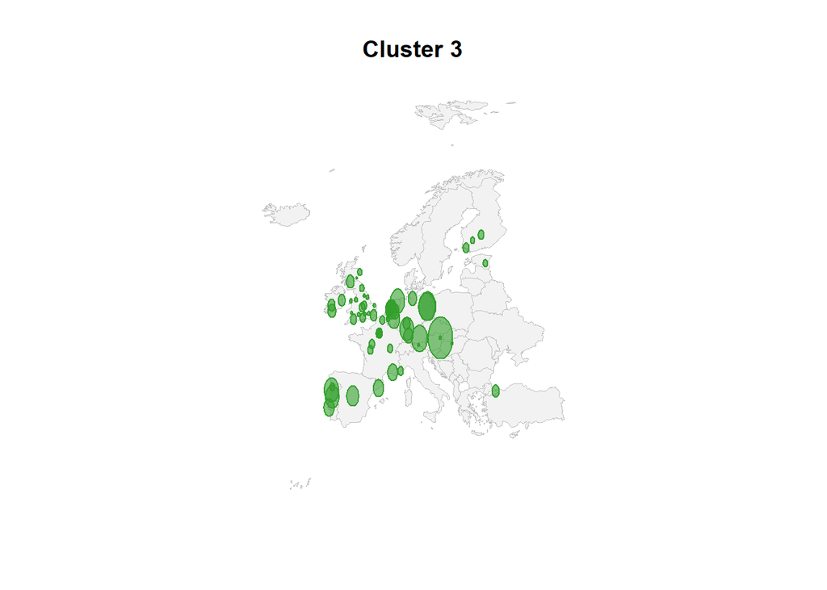

```r
###Cluster 3
# plot the map for the background
map(database= 'world',  region =europe, fill=TRUE,col='#f2f2f2',border ='grey',lwd=0.08)

# plot the network using the geo coordinates
plot.network(main_cluster3,  # pass in the network
             # don't erase the map before drawing the network
             new=FALSE,
             # get coordiantes from vertices and pass in as 2-col matrix
             coord=cbind(main_cluster3%v%'longitude',main_cluster3%v%'latitude'),
             # set a semi-transparent edge color
             edge.col= as.color('grey', opacity= 0),
             # set the vertex size
             vertex.cex = (main_cluster3%v%'wdegree')/200,
             # set a semi transparent vertex color
             vertex.col= as.color(pal7[rep(3+1,(network.size(main_cluster3)))], opacity= 0.6) ,
             vertex.border=as.color(pal7[rep(3+1,(network.size(main_cluster3)))], opacity= 1),
             vertex.lty.width= 0.1,
             # don't jitter the points around
             jitter=FALSE
             )
title(main="Cluster 3")
```

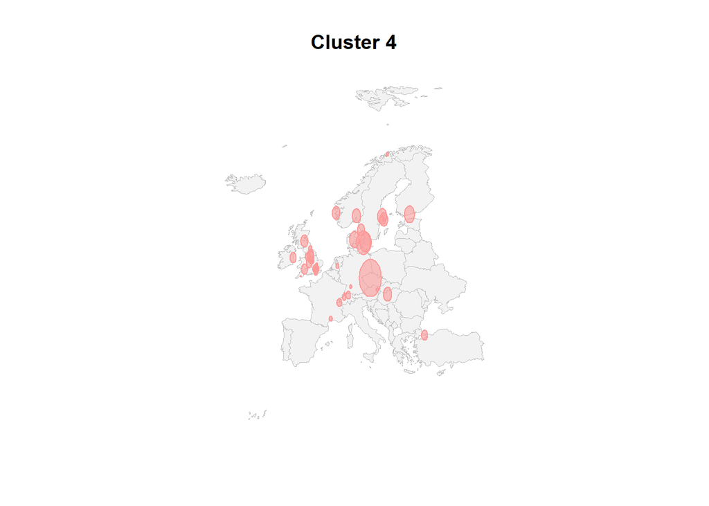

```r
###Cluster 4
# plot the map for the background
map(database= 'world',  region =europe, fill=TRUE,col='#f2f2f2',border ='grey',lwd=0.08)

# plot the network using the geo coordinates
plot.network(main_cluster4,  # pass in the network
             # don't erase the map before drawing the network
             new=FALSE,
             # get coordiantes from vertices and pass in as 2-col matrix
             coord=cbind(main_cluster4%v%'longitude',main_cluster4%v%'latitude'),
             # set a semi-transparent edge color
             edge.col= as.color('grey', opacity= 0),
             # set the vertex size
             vertex.cex = (main_cluster4%v%'wdegree')/200,
             # set a semi transparent vertex color
             vertex.col= as.color(pal7[rep(4+1,(network.size(main_cluster4)))], opacity= 0.6) ,
             vertex.border=as.color(pal7[rep(4+1,(network.size(main_cluster4)))], opacity= 1),
             # don't jitter the points around
             jitter=FALSE
             )
title(main="Cluster 4")
```

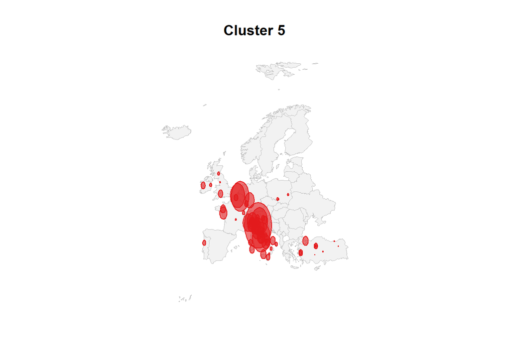

```r
###Cluster 5
# plot the map for the background
map(database= 'world',  region =europe, fill=TRUE,col='#f2f2f2',border ='grey',lwd=0.08)

# plot the network using the geo coordinates
plot.network(main_cluster5,  # pass in the network
             # don't erase the map before drawing the network
             new=FALSE,
             # get coordiantes from vertices and pass in as 2-col matrix
             coord=cbind(main_cluster5%v%'longitude',main_cluster5%v%'latitude'),
             # set a semi-transparent edge color
             edge.col= as.color('grey', opacity= 0),
             # set the vertex size
             vertex.cex = (main_cluster5%v%'wdegree')/200,
             # set a semi transparent vertex color
             vertex.col= as.color(pal7[rep(5+1,(network.size(main_cluster5)))], opacity= 0.6) ,
             vertex.border=as.color(pal7[rep(5+1,(network.size(main_cluster5)))], opacity= 1),
             # don't jitter the points around
             jitter=FALSE
             )
title(main="Cluster 5")
```

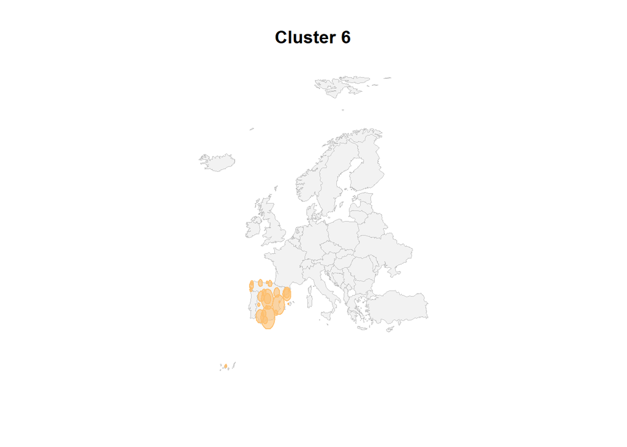

```r
###Cluster 6
# plot the map for the background
map(database= 'world',  region =europe, fill=TRUE,col='#f2f2f2',border ='grey',lwd=0.08)

# plot the network using the geo coordinates
plot.network(main_cluster6,  # pass in the network
             # don't erase the map before drawing the network
             new=FALSE,
             # get coordiantes from vertices and pass in as 2-col matrix
             coord=cbind(main_cluster6%v%'longitude',main_cluster6%v%'latitude'),
             # set a semi-transparent edge color
             edge.col= as.color('grey', opacity= 0),
             # set the vertex size
             vertex.cex = (main_cluster6%v%'wdegree')/200,
             # set a semi transparent vertex color
             vertex.col= as.color(pal7[rep(6+1,(network.size(main_cluster6)))], opacity= 0.6) ,
             vertex.border=as.color(pal7[rep(6+1,(network.size(main_cluster6)))], opacity= 1),
             # don't jitter the points around
             jitter=FALSE
             )
title(main="Cluster 6")
```

Detach packages that will not be needed any more:

```r
detach(package:intergraph)
detach(package:maps)
detach(package:sna)
```

# Question 5

Call libraries that are needed for this question:

```r
require(igraph)
```

Store the estimated coefficients and their standard errors given in the instructions in a vector:

```r
#Estimated Coefficients
coef<- c(0.3329028, 0.3895257, 0.0870115, -0.0016359, 0.5420552, 0.2099600, 2.5899157, 0.5478822)

#Standard Errors
ste<- c(0.0578418, 0.0419288, 0.0415069, 0.0002128, 0.0829627, 0.0416916, 0.0657558, 0.0204300)
```

Calculate the Odd Ratios for each coefficient by exponentiating the logit that was produced by the ERGM. Calculate also the Lower and Upper limits of their Confidence Intervals. Print a table with the results:

```r
or<- exp(coef) #Calculate the Odds Ratios
lci <- exp(coef-1.96*ste) # the lower confidence intervals for 95% confidence
uci <- exp(coef+1.96*ste) # the upper confidence intervals for 95% confidence

oddsratios <- cbind(round(lci, digits = 4), round(or,digits = 4), round(uci,digits = 4)) ## sticking these vectors together, rounding each to 4 decimal places

colnames(oddsratios) <- c("Lower CI","Odds Ratios","Upper CI")
rownames(oddsratios)<- c("nodeifactor.region.Eastern Europe", "nodeifactor.region.Southern Europe", "nodeifactor.region.Western Europe", "nodeicov.rank_ranked", "nodeicov.staff_scaled", "nodeicov.POI_scaled", "mutual", "gwesp.fixed.0.8")

oddsratios
```

```
##                                    Lower CI Odds Ratios Upper CI
## nodeifactor.region.Eastern Europe    1.2455      1.3950   1.5625
## nodeifactor.region.Southern Europe   1.3598      1.4763   1.6027
## nodeifactor.region.Western Europe    1.0057      1.0909   1.1834
## nodeicov.rank_ranked                 0.9979      0.9984   0.9988
## nodeicov.staff_scaled                1.4615      1.7195   2.0232
## nodeicov.POI_scaled                  1.1368      1.2336   1.3387
## mutual                              11.7169     13.3286  15.1621
## gwesp.fixed.0.8                      1.6617      1.7296   1.8002
```

Calculate assortativity for all the vertex attributes available in the metadata file, to facilitate the decision on the additional terms in the ergm:

```r
meta_names<- colnames(hei_metadata) #store column names of the metadata files.
meta_types<-as.matrix(sapply(hei_metadata, class))#store the type of the columns, so that we can treat differently characters from numeric

#Initialize the data frame to store the assortativity values
assortativities_df<- data.frame(meta_names)
assortativities_df['Assortativity'] <- NA

#A loop that goes through all the columns of the metadata file, makes them vertex attribute and calculates the assortativity based on each of them
for(i in 1:length(meta_names))
  {
  if(i==4) next #exclude ther GRID_ID column
  meta_name<- meta_names[i] #create a variable that holds only one of the names of the columns to process in one iteration

  #Treat character columns by using the assortativity.nominal
  if (meta_types[i]=="character"){
    reduced_net <- set.vertex.attribute(reduced_net,name= meta_name, index =V(reduced_net), hei_metadata[,i][hei_metadata$Erasmus.ID  %in% V(reduced_net)$name])

    assort <- assortativity.nominal(reduced_net,factor(vertex_attr(graph=reduced_net, name=meta_name, index = V(reduced_net))), directed = TRUE)

    #Treat numeric columns:
    # - impute the NA values with the maximum value of each column + 1. This is an assumption and we should keep in mind that this imputation might not represent the reality.
    # - calculate assortativity using assortativity function
  }  else {

    max_value<- max(hei_metadata[,meta_name], na.rm = TRUE)#store the maximum value of the column
hei_metadata[is.na(hei_metadata[,meta_name]),meta_name]<- max_value +1#replace the NAs with the maximum value + 1

reduced_net <- set.vertex.attribute(reduced_net,name= meta_name, index =V(reduced_net), hei_metadata[,i][hei_metadata$Erasmus.ID  %in% V(reduced_net)$name])#create the vertex attribute

    assort <- assortativity(reduced_net,vertex_attr(graph=reduced_net, name=meta_name, index = V(reduced_net)), directed = TRUE) #calculate the assortativity

  }
    assortativities_df[i,2]<-assort #store the assortativity value that was calculated to the dataframe that was initially created.
    reduced_net<- delete_vertex_attr(reduced_net, meta_name)#delete the vertex attribute that was calculated, so that we keep the reduced_net clean
}#end of loop

#order the assortativity table
order_assortativities_df <-assortativities_df[order(assortativities_df$Assortativity),]

head(order_assortativities_df) #Print the attributes with the lowest assortativity, hence with the highest DISASSORTATIVITY (since it is negative)
```

```
##                      meta_names Assortativity
## 31 Personnel.expenditure..EURO.   -0.18891119
## 8                  Country_code   -0.11479157
## 30                          NAT   -0.11430664
## 92                      Country   -0.11312898
## 42    Erasmus.incoming.students   -0.09674557
## 21                 ETS_AGGR.EVC   -0.09366086
```

```r
tail(order_assortativities_df) #Print the attributes with the highest ASSORTATIVITY
```

```
##                meta_names Assortativity
## 51               P_collab     0.1697618
## 46                    TCS     0.1731796
## 84 PP_long_dist_collab_lb     0.1733416
## 52           P_int_collab     0.1914177
## 55     P_long_dist_collab     0.2095983
## 4                 GRID_ID            NA
```